# 0529t.Rmd

Saori Takaoka

May 28, 2018

> Read “PCA with Matrix 行列でPCA” before the class on May 29.

> “ax + by + cz = 0” represents a plane in 3D space. Generate many points on the plane and draw them in 3D. Also indicate the direction of a vector (a,b,c) in the drawing.

# The plane in 3D space

Considering the plane described as $ax+by+cz=0$ and the vector $(a,b,c)$. Since degree of freedom on plane is 2, all we have to do is to prepare some function to return $z$ from randomly chosen $(x,y)$ pairs.

```r
library(rgl)
a <- sample(1:10,1)
b <- sample(1:10,1)
c <- sample(1:10,1)

n <- c(a,b,c)

x <- rnorm(100)
y <- rnorm(100)
f <- function(x,y){ -(a*x + b*y)/c }
z <- f(x,y)

f2 <- function(x){ b*x/a }
w <- f2(x)

plot3d(x,y,z,type="p")
abclines3d(0,0,0,a,b,c,add=TRUE,col=2)
planes3d(a,b,c,d=0,add=TRUE,col=3)
```

[interactive chart not shown]

The vector $(a,b,c)$ is a norm vector of the plane $ax+by+cz=0$. To confirm this, calculate the inner product between the vector parallel to the plane and $(a,b,c)$, which should be 0 regardless of the $a,b,c$ value and the direction vector in the plane.

```r
# For example,
a <- rnorm(1)
b <- rnorm(1)
c <- rnorm(1)
f <- function(x,y){ -(a*x + b*y)/c }

# the norm at (x1,y1,z1)
N <- 100
n <- c(a,b,c)

# the direction vector from (x1,y1,z1) on the plane
v <- matrix(rnorm(N*2),N,2)
z <- c()
for(i in 1:N){
  x <- v[i,1]
  y <- v[i,2]
  z1 <- f(x,y)
  z <- rbind(z,z1)
}
v <- cbind(v,z)

inner <- n %*% t(v)
str(inner)
```

```
##  num [1, 1:100] 0 0 0 0 0 ...
##  - attr(*, "dimnames")=List of 2
##   ..$ : NULL
##   ..$ : chr [1:100] "z1" "z1" "z1" "z1" ...
```

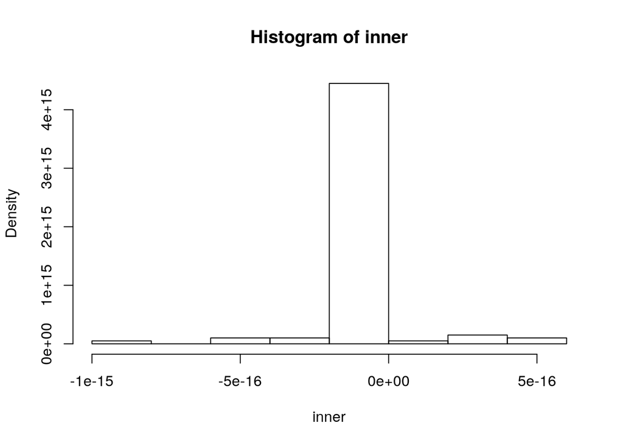

```r
hist(inner,freq=FALSE)
```

The histgram, and also the each component of the matrix `inner` suggests that the inner product of $(a,b,c)$ and any direction vector on the plane always intersect at right angles.

# PCA with Matrix

## Exercise 4-1

```r
d <- 3
n <- 1000
x <- matrix(rnorm(d*n),ncol=d)
x <- apply(x,2,cumsum)
dim(x)
```

```
## [1] 1000    3
```

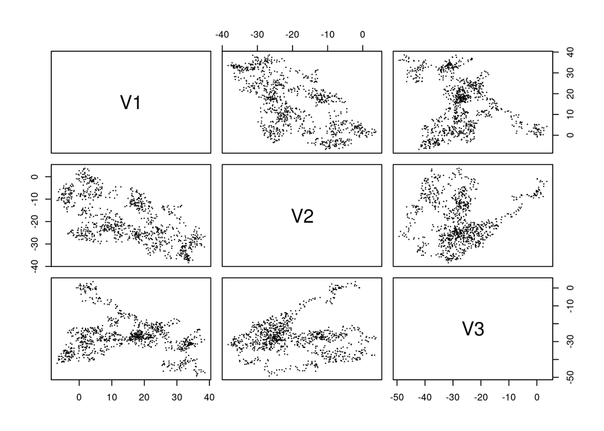

```r
plot(as.data.frame(x),pch=20,cex=0.1)
```

```r
plot3d(x)
```

[interactive chart not shown]

> Answer sample means, variance-covariance matrix.

```r
dat <- as.data.frame(x)
str(dat)
```

```
## 'data.frame':    1000 obs. of  3 variables:
##  $ V1: num  -0.8437 -0.3555 0.0408 0.5243 2.3262 ...
##  $ V2: num  -0.912 -1.063 -1.776 -2.336 -3.253 ...
##  $ V3: num  0.11 0.146 1.319 1.149 2.494 ...
```

```r
m <- c(mean(dat$V1),mean(dat$V2),mean(dat$V3))
m
```

```
## [1]  14.7978 -19.4611 -27.5477
```

```r
var <- var(x)
var
```

```
##           [,1]       [,2]       [,3]
## [1,] 146.78614 -74.381340 -19.353346
## [2,] -74.38134  97.267398   7.635556
## [3,] -19.35335   7.635556  89.294097
```

## Exercise 4-2

> Plot the multivariable normal random numbers based on the mean vector and variance-covariance matrix above.

```r
library(rgl)
x1 <- rnorm(1000, mean=m[1], sd=sqrt(var[1,1]))
y1 <- rnorm(1000, mean=m[2], sd=sqrt(var[2,2]))
z1 <- rnorm(1000, mean=m[3], sd=sqrt(var[3,3]))

x2 <- rnorm(1000, mean=m[1], sd=sqrt(var[1,1]))
y2 <- rnorm(1000, mean=m[2], sd=sqrt(var[2,2]))
z2 <- rnorm(1000, mean=m[3], sd=sqrt(var[3,3]))

a <- cbind(x1,y1,z1)
b <- cbind(x2,y2,z2)
plot3d(a)
plot3d(b,col=2,add=T)
```

[interactive chart not shown]

## Exercise 4-3

> Rotate x by rotation matrix, solve the sample mean and variance-covariance matrix, and compare them with those previous. Make sure that the mean and variance are different from each other.

```r
t <- 30
cos(t) -> ct
sin(t) -> st

Rx <- matrix(c(1,0,0,0,ct,-st,0,st,ct),3,3)
Ry <- matrix(c(ct,0,st,0,1,0,-st,0,ct),3,3)
Rz <- matrix(c(ct,-st,0,st,ct,0,0,0,1),3,3)

x2 <- t(Rx %*% Ry %*% Rz %*% t(x))

m2 <- c(mean(x2[,1]),mean(x2[,2]),mean(x2[,3]))
print("mean x")
```

```
## [1] "mean x"
```

```r
m
```

```
## [1]  14.7978 -19.4611 -27.5477
```

```r
print("mean x2")
```

```
## [1] "mean x2"
```

```r
m2
```

```
## [1] -23.899936  26.989581   7.545926
```

```r
var2 <- var(x2)
print("cov x")
```

```
## [1] "cov x"
```

```r
var
```

```
##           [,1]       [,2]       [,3]
## [1,] 146.78614 -74.381340 -19.353346
## [2,] -74.38134  97.267398   7.635556
## [3,] -19.35335   7.635556  89.294097
```

```r
print("cov x")
```

```
## [1] "cov x"
```

```r
var2
```

```
##           [,1]       [,2]      [,3]
## [1,] 86.841807  -5.985911 -4.771367
## [2,] -5.985911 148.006448 76.304318
## [3,] -4.771367  76.304318 98.499377
```

## Exercise 4-4

> Make sure that the sum of the variance does not change though the values of variance are different. Calculate trace of variance-covariance matrices, and also regard the trace as the sum of the eigen values of variance-covariance matrices.

```r
tr <- sum(diag(var))
tr
```

```
## [1] 333.3476
```

```r
tr2 <- sum(diag(var2))
tr2
```

```
## [1] 333.3476
```

```r
esum <- sum(eigen(var)$value)
esum
```

```
## [1] 333.3476
```

```r
e2sum <- sum(eigen(var2)$value)
e2sum
```

```
## [1] 333.3476
```

## Exercise 4-5

> The sum of the variance of each axis does not change depending on the x axis transformed by rotation, but the distribution of the sum of variance is different. Make sure the fact by the following steps; 1. create a number of random rotation matrices 2. rotate datasets using the matrices 3. calculate the variance along each axis 4. plot the variance in ascending order 5. confirm the change of the distribution.

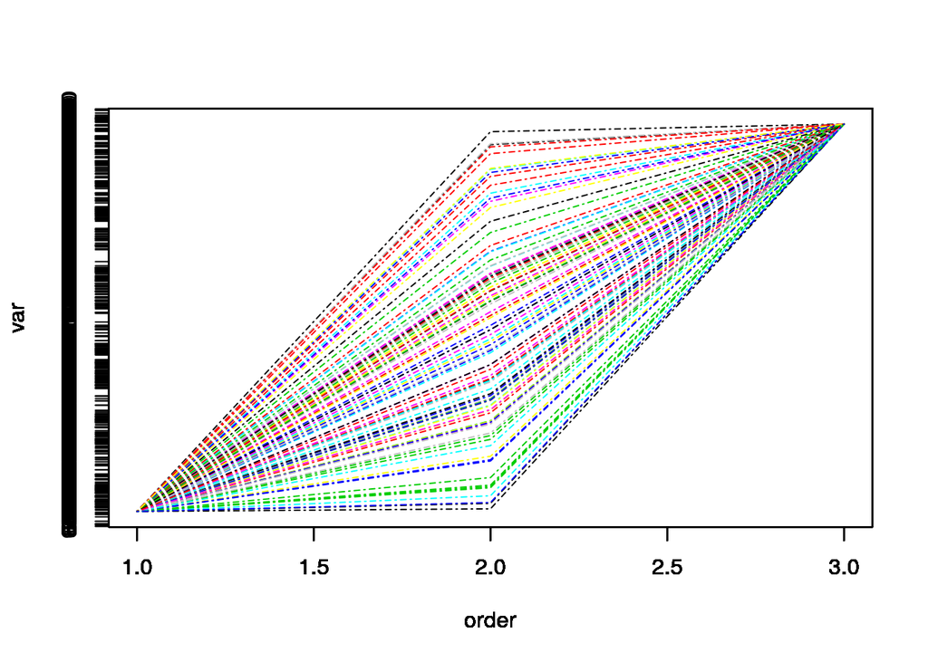

```r
R <- function(t){
  cos(t) -> ct
  sin(t) -> st
  Rx <- matrix(c(1,0,0,0,ct,-st,0,st,ct),3,3)
  Ry <- matrix(c(ct,0,st,0,1,0,-st,0,ct),3,3)
  Rz <- matrix(c(ct,-st,0,st,ct,0,0,0,1),3,3)
  R <- Rx %*% Ry %*% Rz
}

for(i in 1:100){
  t <- rnorm(1)
  xr <- t( R(t) %*% t(x) )
  ev <- diag(var(xr))
  var <- c(min(ev),median(ev),max(ev))
  order <- c(1,2,3)
  plot(order,var,xlab="order",ylab="var",type="l",col=i, lty=4)
  par(new=T)
}
```

> Plot the variance of each axis obtained by rotation which diagonize variance-covariance matrix.

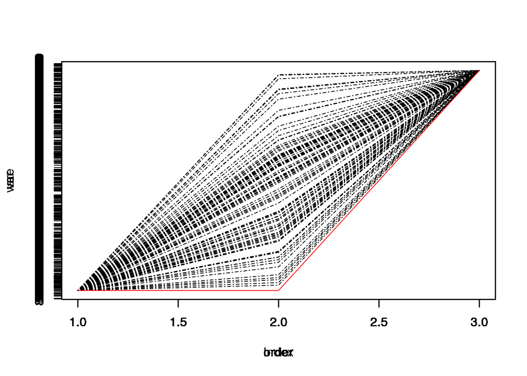

```r
R <- function(t){
  cos(t) -> ct
  sin(t) -> st
  Rx <- matrix(c(1,0,0,0,ct,-st,0,st,ct),3,3)
  Ry <- matrix(c(ct,0,st,0,1,0,-st,0,ct),3,3)
  Rz <- matrix(c(ct,-st,0,st,ct,0,0,0,1),3,3)
  R <- Rx %*% Ry %*% Rz
}

for(i in 1:100){
  t <- rnorm(1)
  xr <- t( R(t) %*% t(x) )
  ev <- diag(var(xr))
  var <- c(min(ev),median(ev),max(ev))
  order <- c(1,2,3)
  plot(order,var,xlab="order",ylab="var",type="l",col=1, lty=4)
  par(new=T)
}
var.e <- diag(eigen(var(x))$value)
vare <- c(min(var.e),median(var.e),max(var.e))

plot(vare,type="l",col=2)
```

> Increase the number of variables.

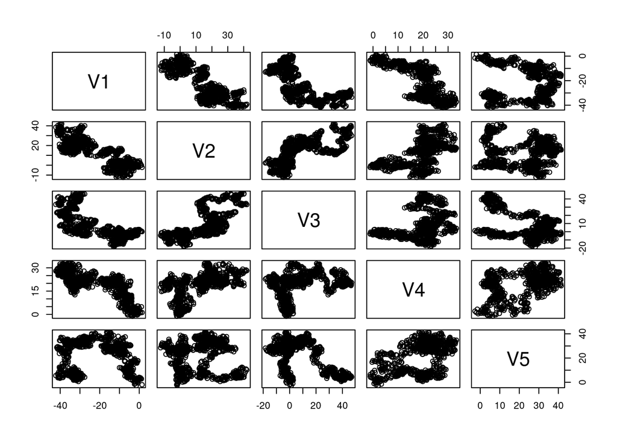

```r
d <- 10
n <- 1000
X <- matrix(rnorm(d*n),ncol=d)
X <- apply(X,2,cumsum)

plot(as.data.frame(X[,1:5],pch=20,cex=0.1))
```

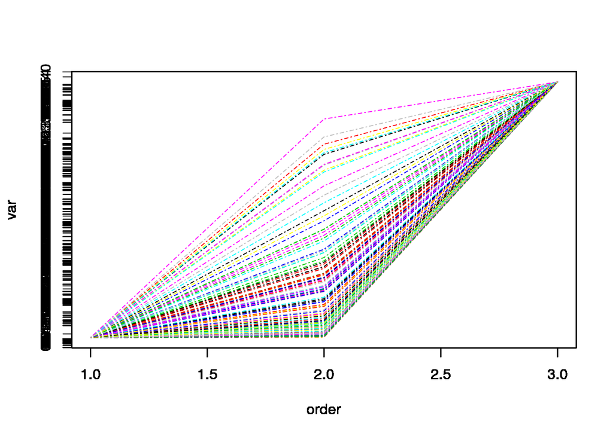

```r
Var.e <- diag(eigen(var(X))$value)
chnum <- choose(n=10,k=3)
comb <- combn(x=diag(Var.e),m=3)

for(i in 1:chnum){
  Vare <- c(min(comb[,i]),median(comb[,i]),max(comb[,i]))
  order <- c(1,2,3)
  plot(order,Vare,xlab="order",ylab="var",type="l",col=i, lty=4)
  par(new=T)
}
```

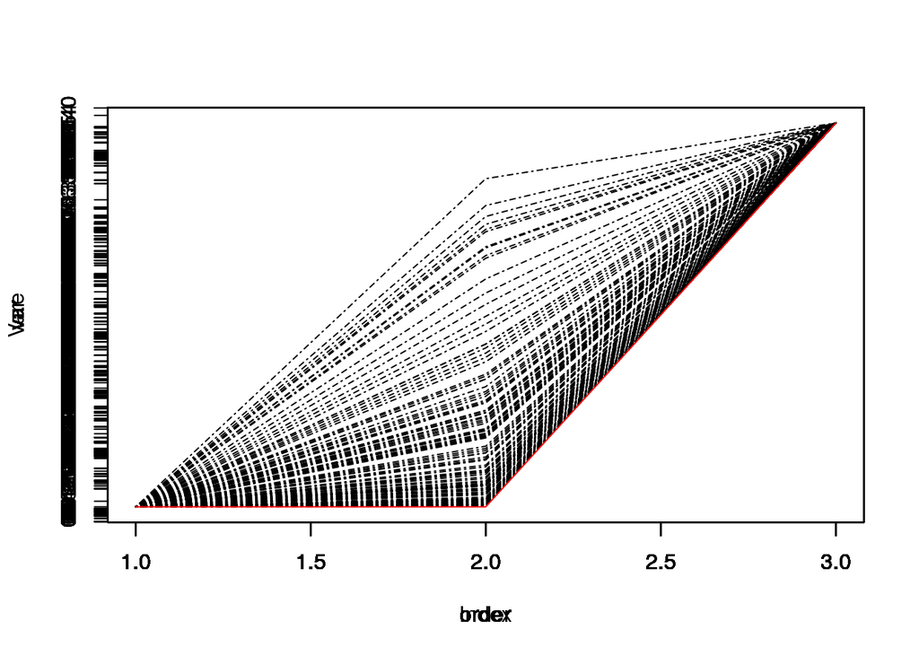

```r
Var.e <- diag(eigen(var(X))$value)
chnum <- choose(n=10,k=3)
comb <- combn(x=diag(Var.e),m=3)

for(i in 1:chnum){
  Vare <- c(min(comb[,i]),median(comb[,i]),max(comb[,i]))
  order <- c(1,2,3)
  plot(order,Vare,xlab="order",ylab="var",type="l",col=1, lty=4)
  par(new=T)
}

Vare <- c(min(Var.e),median(Var.e),max(Var.e))

plot(Vare,type="l",col=2)
```